# okean_roms_slice

## ROMS data extraction

#### roms.His and roms.Grid (roms.MHis and roms.MGrid for nesting configurations)

- roms.His can be used to load his/avg/rst/clm files
- It accepts the grid file as second argument if grid variables are not included in the main file.
- roms.His.grid stores the grid object which can also be loaded with roms.Grid.
- For nested applications there is also roms.MHis and roms.MGrid

```python
import pylab as pl
import numpy as np

f='http://centolo.co.ieo.es:8080/thredds/dodsC/flor/test/avg_flor_1.nc4'
from okean import roms
r=roms.His(f)
```

### roms.Grid

```python
#g=roms.Grid(f)
# or in this case:
g=r.grid
print(g.h.shape) # data is loaded *only when needed*, ie, g.h was empty until now
```

```
(137, 237)
```

#### quick plot:

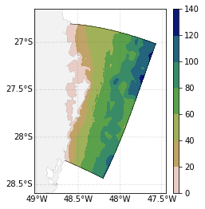

```python
# the quick plots rely on the vis module

# will 1st set the default fig size (just for better visualisation)
from okean import vis
vis.param['figure.figsize']=3.2,4

g.plot();# or g.plot(figsize=(3.2,4)) if fig size not set in vis module
```

#### domain resolution

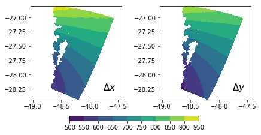

```python
x,y,dx,dy=g.resolution()

pl.figure(figsize=(6,2.7))
ax0=pl.axes((0.1,0.2,0.35,0.8))
ax1=pl.axes((0.6,0.2,0.35,0.8))
cbar=pl.axes((0.25,0.02,0.5,0.04))

# finding nice contour values:
from okean import ticks
vals=ticks.loose_label(np.ma.min((dx,dy)),np.ma.max((dx,dy)),10)

ax0.contourf(x,y,dx,vals)
h=ax1.contourf(x,y,dy,vals)
pl.colorbar(h,cax=cbar,orientation='horizontal')
[a.axis('equal') for a in (ax0,ax1)];

ax0.text(0.8,0.1,'$\Delta x$',transform=ax0.transAxes,fontsize=15)
ax1.text(0.8,0.1,'$\Delta y$',transform=ax1.transAxes,fontsize=15);
```

#### domain boundary

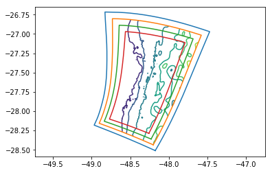

```python
xb0,yb0=g.border()
for i in range(-10,30,10):
    xb,yb=g.border(margin=i)
    pl.plot(xb,yb)

pl.contour(g.lon,g.lat,g.h)
pl.axis('equal')
d=0.15
pl.axis([xb0.min()-d,xb0.max()+d,yb0.min()-d,yb0.max()+d]);
```

#### map projection

```
{'resolution': 'i', 'projection': 'lcc', 'lat_1': -28.02649230631346, 'lat_2': -27.210541500101353, 'lat_0': -27.618516903207407, 'lon_0': -48.24052925935019, 'width': 154480.47122921897, 'height': 215411.01283999643}
```

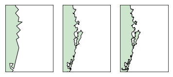

```python
print(g.proj_info['basemap_opts'])

fig,ax=pl.subplots(1,3)
for i,res in enumerate('lih'):
    g.proj_info['basemap_opts']['resolution']=res
    m=g.get_projection()
    m.drawcoastlines(ax=ax[i])
    m.fillcontinents(ax=ax[i],color='g',alpha=0.2)
```

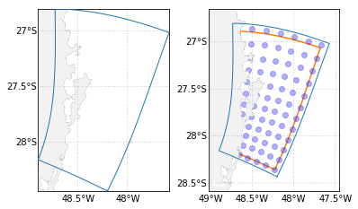

```python
# play with projections and vis module:
fig,ax=pl.subplots(1,2)
pl.subplots_adjust(wspace=0.3)

# default data projection:
from okean import vis
d=vis.Data(xb0,yb0)
d.plot(ax=ax[0],proj=1,plot__zorder=1e3)

# default grid projection:
d.set_projection(g.proj_info['basemap_opts'])
d.plot(ax=ax[1],proj=1,plot__zorder=1e3)

# add some new data:
xb,yb=d.map(*r.grid.border(margin=10))
ax[1].plot(xb,yb)
j,i=20,20
x,y=d.map(r.grid.lon[j//2::j,i//2::i],r.grid.lat[j//2::j,i//2::i])
ax[1].plot(x,y,'bo',alpha=.3);
```

### roms.His

#### slice k

slice along s-level

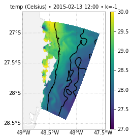

```python
o=r.slicek('temp',-1,-1)
o.plot(clim=(27,30))
```

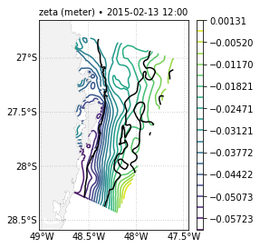

```python
o=r.slicek('zeta',-1,-1)
o.plot(field__plot='contour')
```

Returned object can be used to plot directly (without using the vis module), with several options.

Or you can use the data stored in the object:

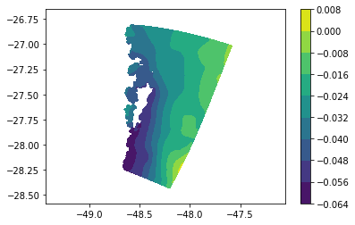

```python
pl.contourf(o.x,o.y,o.v)
pl.colorbar()

pl.axis('equal')
d=0.15
pl.axis([xb0.min()-d,xb0.max()+d,yb0.min()-d,yb0.max()+d]);
```

All extras in the plot (usually the bottom) are stored in the extra attribute. All extras can also be plotted alone, e.g.:

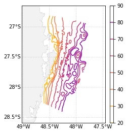

```python
o.extra[0].plot(cvals=range(20,100,10),field__cmap=pl.cm.plasma_r)
```

#### slice iso

iso surfaces can be calculated using fixed or variable iso value

- using fixed iso:

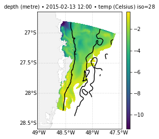

```python
o=r.sliceiso('temp',28,-1)
o.plot()
```

- using variable value iso, e.g. the surface temp -1℃

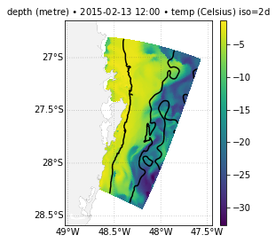

```python
sst=r.slicek('temp',-1,-1).v
o=r.sliceiso('temp',sst-1,-1)
o.plot()
```

#### slice z

slice at z-const, can use a fixed or variable depths:

- using fixed depth:

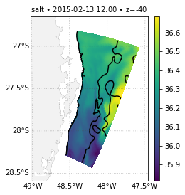

```python
o=r.slicez('salt',-40,-1)
o.plot()
```

- using variable depths, e.g. the middle of the water column:

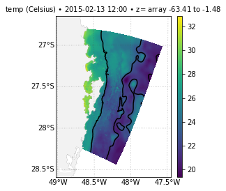

```python
o=r.slicez('temp',-r.grid.h/2,-1)
o.plot()
```

slicez interpolates in the vertical linearly or using splines (default):

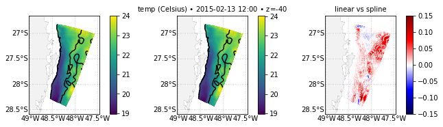

```python
o0=r.slicez('temp',-40,-1)
o1=r.slicez('temp',-40,-1,spline=False)

pl.figure(figsize=(9,2.5))
ax,cax=[],[]
x0=0
for i in range(3):
    x0=x0+1/3.
    pos=x0+0.1,0.2,0.2,0.8
    cpos=pos[0]+pos[2]+0.003,pos[1],0.015,pos[3]
    ax+=[pl.axes(pos)]
    cax+=[pl.axes(cpos)]


o0.plot(ax=ax[0],cbax=cax[0],labels=False)
o1.plot(ax=ax[1],cbax=cax[1])

o2=vis.Data(o0.x,o0.y,o1.v-o0.v)
o2.copy_projection(o0)
o2.plot(ax=ax[2],cbax=cax[2],cmap='seismic',clim=(-0.15,0.15))
o2.draw_label('title','linear vs spline')
```

What if depth is very low, inside the tidal range, for instance. In such case, the option surf_mask may be used to repeat or not the data of the last s-level:

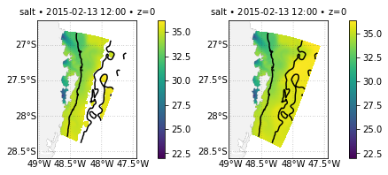

```python
o0=r.slicez('salt',-0.9,-1)
o1=r.slicez('salt',-0.9,-1,surf_mask=False)

pl.figure(figsize=(6,2.7))
ax0=pl.axes((0.1,0.2,0.35,0.8))
ax1=pl.axes((0.6,0.2,0.35,0.8))

cbax0=pl.axes((0.46,0.2,0.02,0.8))
cbax1=pl.axes((0.96,0.2,0.02,0.8))

o0.plot(ax=ax0,cbax=cbax0)
o1.plot(ax=ax1,cbax=cbax1)
```

#### slice i,j

slice along xi,eta

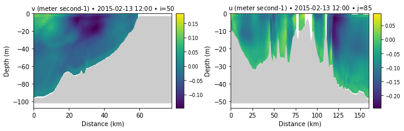

```python
oi=r.slicei('v',50,-1)
oj=r.slicej('u',85,-1)

pl.figure(figsize=(9,2.7))
ax0=pl.axes((0.1,0.2,0.35,0.8))
ax1=pl.axes((0.6,0.2,0.35,0.8))

cbax0=pl.axes((0.46,0.2,0.02,0.8))
cbax1=pl.axes((0.96,0.2,0.02,0.8))

oi.plot(ax=ax0,cbax=cbax0)
oj.plot(ax=ax1,cbax=cbax1)

for a in [cbax0,cbax1]:
    a.tick_params(labelsize=8)
```

#### slice ll

slice along lon x lat path

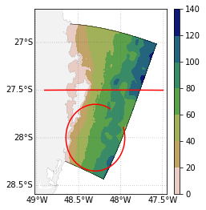

```python
import numpy as np
y0,x0=-27.5,-48.9
y1,x1=-27.5, -47.5
x=np.linspace(x0,x1,50)
y=np.linspace(y0,y1,50)

if 0:
    x2=-48
    y2=-26.8
    xx=np.linspace(x1,x2,50)
    yy=np.linspace(y1,y2,50)
    x=np.hstack((x,xx))
    y=np.hstack((y,yy))

xc=-48.3+0.35*np.cos(np.linspace(np.pi/3,2.1*np.pi,100))
yc=-28+0.35*np.sin(np.linspace(np.pi/3,2.1*np.pi,100))

q=r.grid.plot()
xm,ym=q.map(x,y)
q.ax.plot(xm,ym,'r',zorder=1e3);

xcm,ycm=q.map(xc,yc)
q.ax.plot(xcm,ycm,'r',zorder=1e3);
```

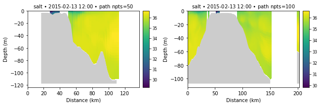

```python
ol=r.slicell('salt',x,y,-1)
oc=r.slicell('salt',xc,yc,-1)

pl.figure(figsize=(9,2.7))
ax0=pl.axes((0.1,0.2,0.35,0.8))
ax1=pl.axes((0.6,0.2,0.35,0.8))

cbax0=pl.axes((0.46,0.2,0.02,0.8))
cbax1=pl.axes((0.96,0.2,0.02,0.8))

ol.plot(ax=ax0,cbax=cbax0)
oc.plot(ax=ax1,cbax=cbax1)

for a in [cbax0,cbax1]:
    a.tick_params(labelsize=8)
```

#### slice uv

horizontal slices for currents

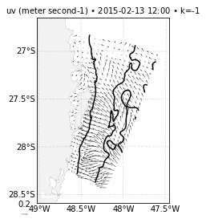

```python
o=r.sliceuv('surface',-1)
o.plot(dij=(7,7),vfield__options=dict(units='width',scale=4))
```

#### horizontal slices of derived variables

(hdiv, rvort, ke, speed, okubo)

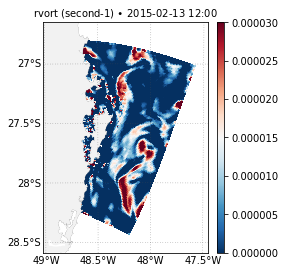

```python
o=r.slice_derived('vort','surface',-1)
o.plot(clim=(0,0.00003),field__cmap=pl.cm.RdBu_r)
```

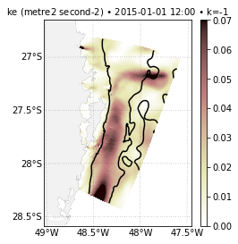

```python
o=r.slice_derived('ke','surface',0)
o.plot(field__clim=(0,0.07),field__cmap=pl.cm.pink_r)
```

#### time series

time_series method can be used to extract time series at some depth or s-level and at all s-levels. It can also be used to extract vertical profiles

- at all s-levels:

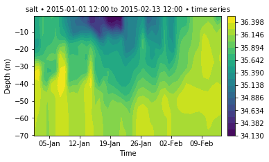

```python
o=r.time_series('salt',-48,-27.5)
o.plot(figsize=(5,3),field__plot='contourf')

# adjust xticks:
mdates=pl.matplotlib.dates
loc = mdates.WeekdayLocator(byweekday=mdates.MO)
o.ax.xaxis.set_major_locator(loc)
o.ax.xaxis.set_major_formatter(mdates.DateFormatter('%d-%b'))
```

- at fixed depth or s-level:

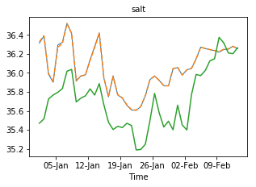

```python
o=r.time_series('salt',-48,-27.5,depth=-40)
o1=r.time_series('salt',-48,-27.5,depth=-40,spline=False)
o2=r.time_series('salt',-48,-27.5,depth=20) # s-level

o.plot(figsize=(5,3))
o.ax.plot(o1.t,o1.v,'--')
o.ax.plot(o2.t,o2.v)
# or:
# o.extra+=[o1,o2]
# o.plot()

o.ax.xaxis.set_major_locator(loc)
o.ax.xaxis.set_major_formatter(mdates.DateFormatter('%d-%b'))
```

- variable without depth dimension:

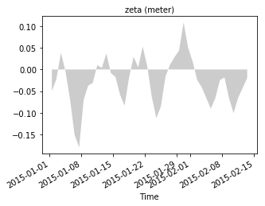

```python
o=r.time_series('zeta',-48,-27.5)
o.plot(figsize=(5,3),d1__plot='fill_between')

# rotate xticks
for label in o.ax.get_xticklabels(which='major'):
    label.set_ha('right')
    label.set_rotation(30)
```

- variable without time and depth dimensions:

```python
o=r.time_series('h',-48,-27.5)
print('nearest longitude = %.4f'%o.x)
print('nearest latitude  = %.4f'%o.y)
print('depth = %.4f m'%o.v)
```

```
nearest longitude = -47.9976
nearest latitude  = -27.5037
depth = 71.3670 m
```

- vertical profiles:

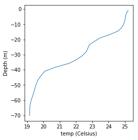

```python
o=r.time_series('temp',-48,-27.5,times=0)
o.plot(figsize=(4,4))
```

### Misc

- s-levels

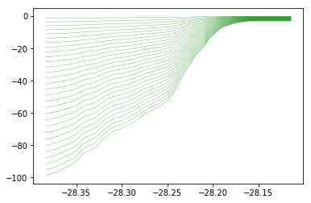

```python
sr=r.s_levels(0,i=10)
pl.plot(r.grid.lat[:,10],sr.T,'g',lw=0.5,alpha=0.5);
```

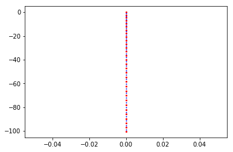

```python
# w vs rho points:
# loc indicates horizontal (r, u, or v) and vertical location (r or w)
sw=r.s_levels(0,i=10,loc='rw')

pl.plot(np.zeros(sw.shape[0]),sw[:,0],'ro',ms=2)
pl.plot(np.zeros(sr.shape[0]),sr[:,0],'b+',ms=2);
```

### Nesting configurations

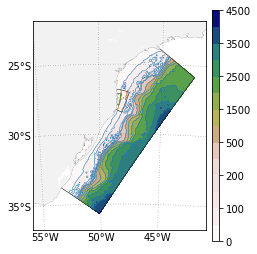

```python
files=[]
p='http://centolo.co.ieo.es:8080/thredds/dodsC/flor/'
files+=[p+'daily_averages_2015d0']
files+=[p+'daily_averages_2015d1']
files+=[p+'daily_averages_2015d2']
r=roms.MHis(files)
r.grid.plot()
```

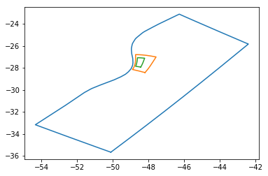

```python
xb,yb=r.grid.border()
pl.plot(xb,yb);
```

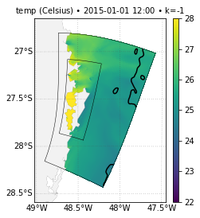

```python
o=r.slicek('temp',-1,0)
o.plot(clim=(22,28))
```

it is still possible to plot each domain individually:

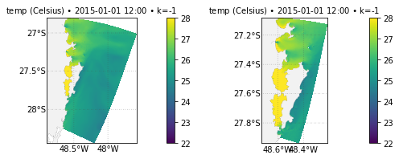

```python
pl.figure(figsize=(7,2.7))
ax0=pl.axes((0.1,0.2,0.35,0.8))
ax1=pl.axes((0.6,0.2,0.35,0.8))

cbax0=pl.axes((0.46,0.2,0.02,0.8))
cbax1=pl.axes((0.96,0.2,0.02,0.8))

# during the previous o.plot a projection was set for all o elements
# need to remove them to have new projections for each domain
o[1].rm_projection()
o[2].rm_projection()

o[1].plot(ax=ax0,cbax=cbax0,extras=0)
o[2].plot(ax=ax1,cbax=cbax1,extras=0)
```

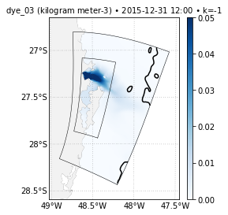

```python
r=roms.MHis(files[1:])
o=r.slicek('dye_03',-1,-1)
o.plot(cmap=pl.cm.Blues,clim=(0,.05))
```

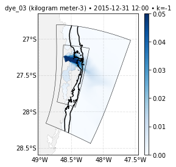

```python
for i in o.find('bathy'): i.config['field.cvals']=20,40
o.plot()
```